# DAND - Exploratory Data Analysis Project

Guillermo Naranjo

October 2, 2017

# DataSet:

# Univariate Plots Section

```
## 'data.frame':    1599 obs. of  14 variables:
##  $ fixed.acidity       : num  7.4 7.8 7.8 11.2 7.4 7.4 7.9 7.3 7.8 7.5 ...
##  $ volatile.acidity    : num  0.7 0.88 0.76 0.28 0.7 0.66 0.6 0.65 0.58 0.5 ...
##  $ citric.acid         : num  0 0 0.04 0.56 0 0 0.06 0 0.02 0.36 ...
##  $ residual.sugar      : num  1.9 2.6 2.3 1.9 1.9 1.8 1.6 1.2 2 6.1 ...
##  $ chlorides           : num  0.076 0.098 0.092 0.075 0.076 0.075 0.069 0.065 0.073 0.071 ...
##  $ free.sulfur.dioxide : num  11 25 15 17 11 13 15 15 9 17 ...
##  $ total.sulfur.dioxide: num  34 67 54 60 34 40 59 21 18 102 ...
##  $ density             : num  0.998 0.997 0.997 0.998 0.998 ...
##  $ pH                  : num  3.51 3.2 3.26 3.16 3.51 3.51 3.3 3.39 3.36 3.35 ...
##  $ sulphates           : num  0.56 0.68 0.65 0.58 0.56 0.56 0.46 0.47 0.57 0.8 ...
##  $ alcohol             : num  9.4 9.8 9.8 9.8 9.4 9.4 9.4 10 9.5 10.5 ...
##  $ quality             : int  5 5 5 6 5 5 5 7 7 5 ...
##  $ quality_level       : Factor w/ 6 levels "3","4","5","6",..: 3 3 3 4 3 3 3 5 5 3 ...
##  $ quality_group       : Factor w/ 4 levels "1","2","3","4": 2 2 2 3 2 2 2 4 4 2 ...
```

> Redwine quality varible contains six leves, two of them (3 low quality wines and 8 high quality wines) have few cases. I will not apply test significance of those levels but to have a better understanding for colors I group:
- level 3 and 4 as Cat1
- levels 7 and 8 as Cat4.

#### Acidity / basis variables

The following grid shows the distribution of acidity/basis variables.

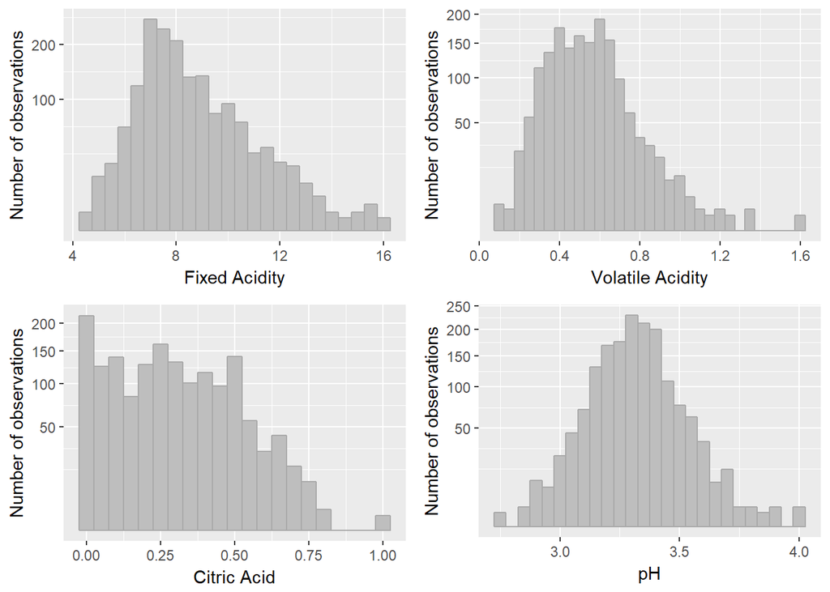

fixed.acidity

```
##    Min. 1st Qu.  Median    Mean 3rd Qu.    Max.
##    4.60    7.10    7.90    8.32    9.20   15.90
```

volatile.acidity

```
##    Min. 1st Qu.  Median    Mean 3rd Qu.    Max.
##  0.1200  0.3900  0.5200  0.5278  0.6400  1.5800
```

citric.acid

```
##    Min. 1st Qu.  Median    Mean 3rd Qu.    Max.
##   0.000   0.090   0.260   0.271   0.420   1.000
```

pH

```
##    Min. 1st Qu.  Median    Mean 3rd Qu.    Max.
##   2.740   3.210   3.310   3.311   3.400   4.010
```

> **Courious**: are modals related to quality?

#### Alcohol and Sulphates

The following grid shows the distribution of alcohol and sulphated variables.

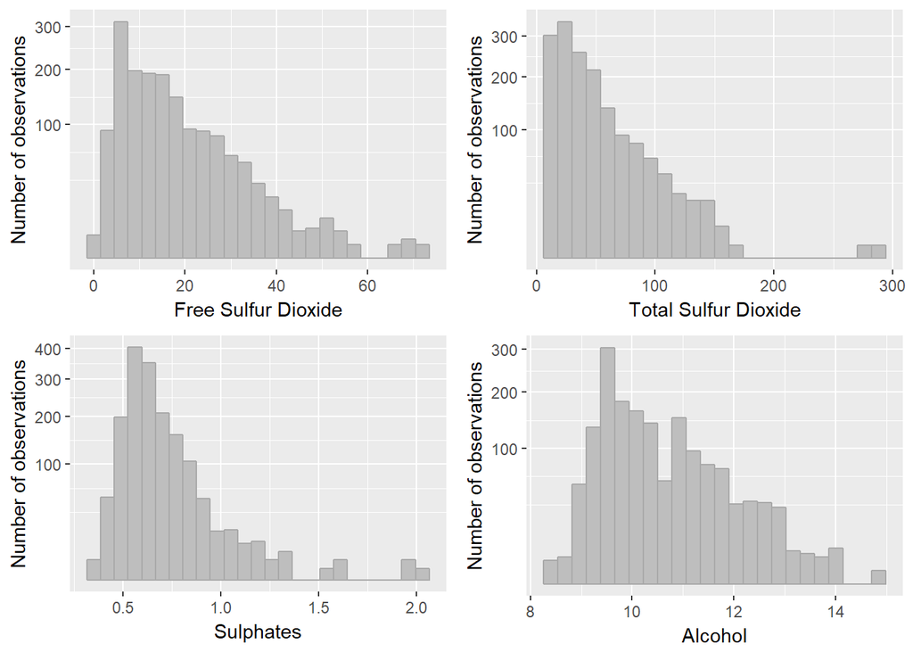

free.sulfur.dioxide

```
##    Min. 1st Qu.  Median    Mean 3rd Qu.    Max.
##    1.00    7.00   14.00   15.87   21.00   72.00
```

total.sulfur.dioxide

```
##    Min. 1st Qu.  Median    Mean 3rd Qu.    Max.
##    6.00   22.00   38.00   46.47   62.00  289.00
```

sulphates

```
##    Min. 1st Qu.  Median    Mean 3rd Qu.    Max.
##  0.3300  0.5500  0.6200  0.6581  0.7300  2.0000
```

alcohol

```
##    Min. 1st Qu.  Median    Mean 3rd Qu.    Max.
##    8.40    9.50   10.20   10.42   11.10   14.90
```

#### Other less interesting variables

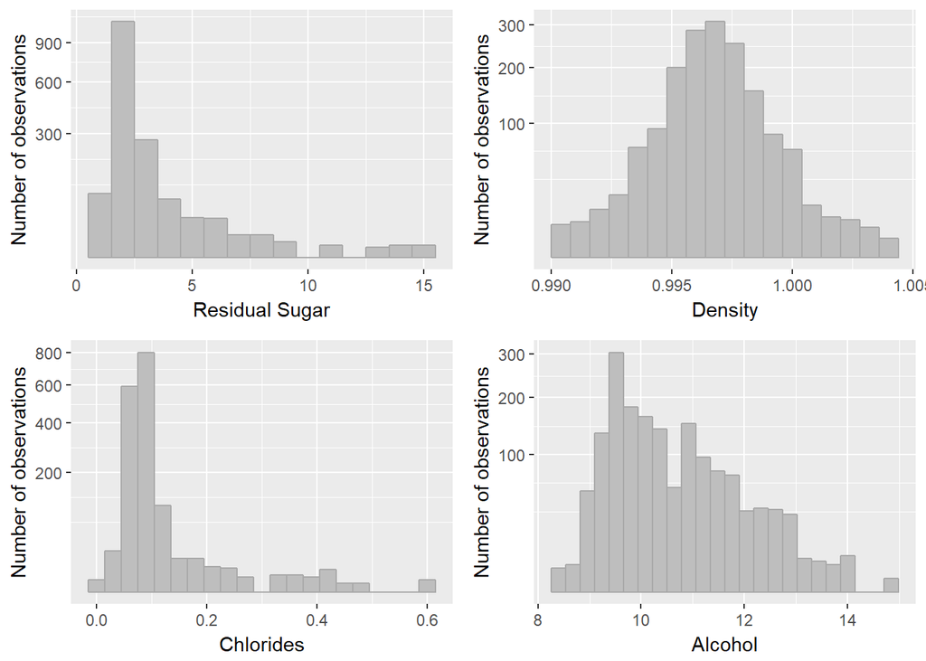

residual.sugar

```
##    Min. 1st Qu.  Median    Mean 3rd Qu.    Max.
##   0.900   1.900   2.200   2.539   2.600  15.500
```

density

```
##    Min. 1st Qu.  Median    Mean 3rd Qu.    Max.
##  0.9901  0.9956  0.9968  0.9967  0.9978  1.0037
```

chlorides

```
##    Min. 1st Qu.  Median    Mean 3rd Qu.    Max.
## 0.01200 0.07000 0.07900 0.08747 0.09000 0.61100
```

- If we remove some outlier from Chlorides and Residual Sugar distributions they look unimodal, with some “special cases” at higher sugar/chlorides level.
- Density looks completely normal distribuided with peak at 0.9968.

#### Boxplots

Now, lets have a closer looks at Residual sugar, Chlorides and Sulphates to see how outliers affect each variable.

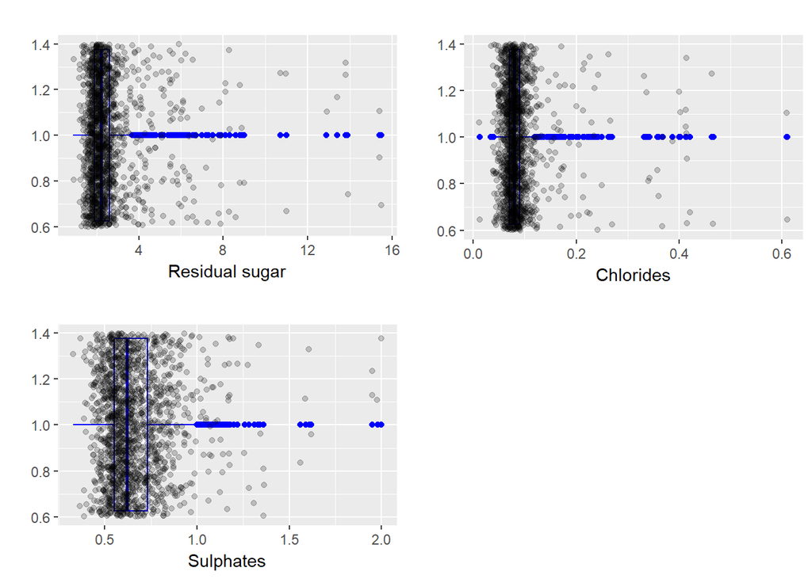

It seems both residual sugar and chlorides have some outliers that could affect the distribution. So, there are few cases where wine is either sweet or salty.

> outlier detections is applied.

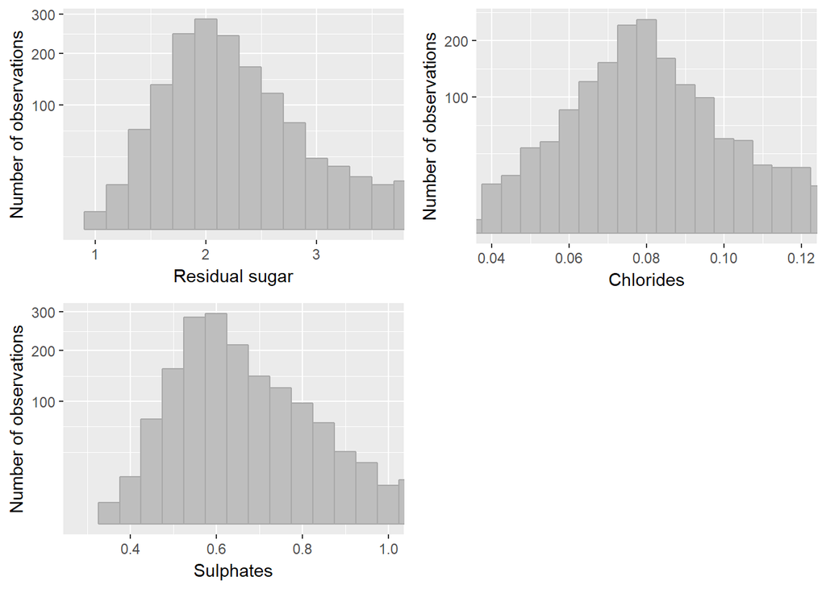

# Univariate Analysis

**What is the structure of your dataset?**

Our dataset contains 1599 observations and 11 quantitative variables. This is a tidy data set that describes each observation (red variants of the Portuguese “Vinho Verde” wine) with 11 qualitative physicochemical input variables and 1 output variable: quality. I’ll try to analyze which variables define red wine quality for this particular sample. There are some interesting facts about variables that could relate to quality:

- Volatile acidity: at too high of levels can lead to unpleasant, vinegar taste.
- Citric acid: can add ‘freshness’ and flavor to wines.
- Free sulfur dioxide: prevents microbial growth and the oxidation of wine (SO2).
- Total sulfur dioxide: over 50 ppm becomes evident in the nose and taste.
- Density: dependent variable of alcohol and sugar.
- pH: how acid or basic is the wine, most wines are between 3-4 on the pH scale.
- Sulphates: additive which can contribute to S02 levels.
- Alcohol: the percent alcohol content of the wine.

**What is/are the main feature(s) of interest in your dataset?**

**What other features in the dataset do you think will help support your** **investigation into your feature(s) of interest?**

Since Fixed acidity and pH are related to citric and volatile acidity those are other variables I would like to analyze. As for alcohol, it looks like there is a relation to density and sugar residual that we need to verify.

**Did you create any new variables from existing variables in the dataset?**

Not yet but Density, pH and Fixed acidity can eventually be removed if we managed to conclude they can be highly correlated to other varibles linearly related to quality.

**Of the features you investigated, were there any unusual distributions?**

Sugar residuals, chlorides, sulphates and total sulfur dioxide look normal once outliers are applied. Residual Sugar and Sulphates are even alike.

Some are normal distributions like Ph and Density but in most cases the distributions are right skewed. I applied a **scale_y_sqrt** to the plots to amplify the modals and see other patterns.

# Bivariate Plots Section

Since our Redwine data set contains only continuous variables we are able to apply Pearson correlation.

```
##         F.Acid V.Acid C.Acid RSugar Chlor FreeSD TotalSD Dens.    pH Sulph
## F.Acid    1.00  -0.26   0.67   0.11  0.09  -0.15   -0.11  0.67 -0.68  0.18
## V.Acid   -0.26   1.00  -0.55   0.00  0.06  -0.01    0.08  0.02  0.23 -0.26
## C.Acid    0.67  -0.55   1.00   0.14  0.20  -0.06    0.04  0.36 -0.54  0.31
## RSugar    0.11   0.00   0.14   1.00  0.06   0.19    0.20  0.36 -0.09  0.01
## Chlor     0.09   0.06   0.20   0.06  1.00   0.01    0.05  0.20 -0.27  0.37
## FreeSD   -0.15  -0.01  -0.06   0.19  0.01   1.00    0.67 -0.02  0.07  0.05
## TotalSD  -0.11   0.08   0.04   0.20  0.05   0.67    1.00  0.07 -0.07  0.04
## Dens.     0.67   0.02   0.36   0.36  0.20  -0.02    0.07  1.00 -0.34  0.15
## pH       -0.68   0.23  -0.54  -0.09 -0.27   0.07   -0.07 -0.34  1.00 -0.20
## Sulph     0.18  -0.26   0.31   0.01  0.37   0.05    0.04  0.15 -0.20  1.00
## Alcoh    -0.06  -0.20   0.11   0.04 -0.22  -0.07   -0.21 -0.50  0.21  0.09
## Qual.     0.12  -0.39   0.23   0.01 -0.13  -0.05   -0.19 -0.17 -0.06  0.25
##         Alcoh Qual.
## F.Acid  -0.06  0.12
## V.Acid  -0.20 -0.39
## C.Acid   0.11  0.23
## RSugar   0.04  0.01
## Chlor   -0.22 -0.13
## FreeSD  -0.07 -0.05
## TotalSD -0.21 -0.19
## Dens.   -0.50 -0.17
## pH       0.21 -0.06
## Sulph    0.09  0.25
## Alcoh    1.00  0.48
## Qual.    0.48  1.00
```

Besides Free Sulfate Dioxide and Free Sulfate Dioxide (that are closely related), lets look at other interestingly related variables:

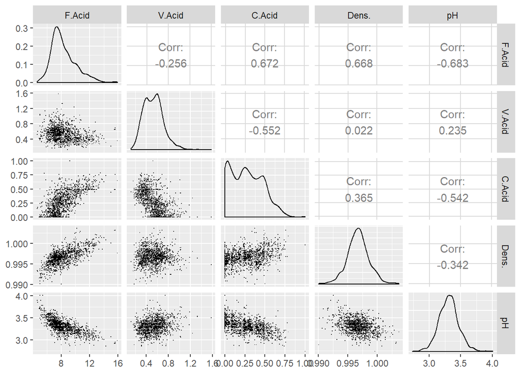

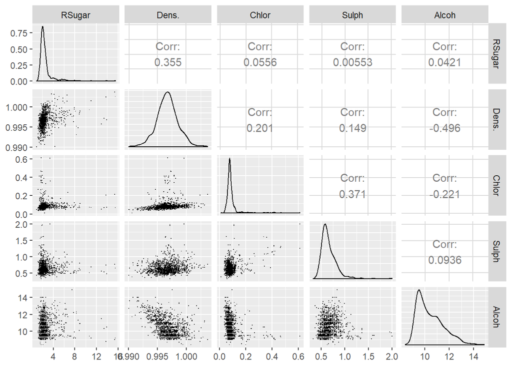

And finally lets plot the the variables more correlated to quality with conditional summaries:

```
##              [,1]   [,2]    [,3]    [,4]    [,5]   [,6]
## quality     3.000  4.000   5.000   6.000   7.000  8.000
## fa_Median   7.500  7.500   7.800   7.900   8.800  8.250
## va_Median   0.845  0.670   0.580   0.490   0.370  0.370
## ca_Median   0.035  0.090   0.230   0.260   0.400  0.420
## rs_Median   2.100  2.100   2.200   2.200   2.300  2.100
## ch_Median   0.090  0.080   0.081   0.078   0.073  0.070
## fs_dMedian  6.000 11.000  15.000  14.000  11.000  7.500
## ts_dMedian 15.000 26.000  47.000  35.000  27.000 21.500
## de_Median   0.998  0.996   0.997   0.997   0.996  0.995
## pH_Median   3.390  3.370   3.300   3.320   3.280  3.230
## su_Median   0.545  0.560   0.580   0.640   0.740  0.740
## al_Median   9.925 10.000   9.700  10.500  11.500 12.150
## n          10.000 53.000 681.000 638.000 199.000 18.000
```

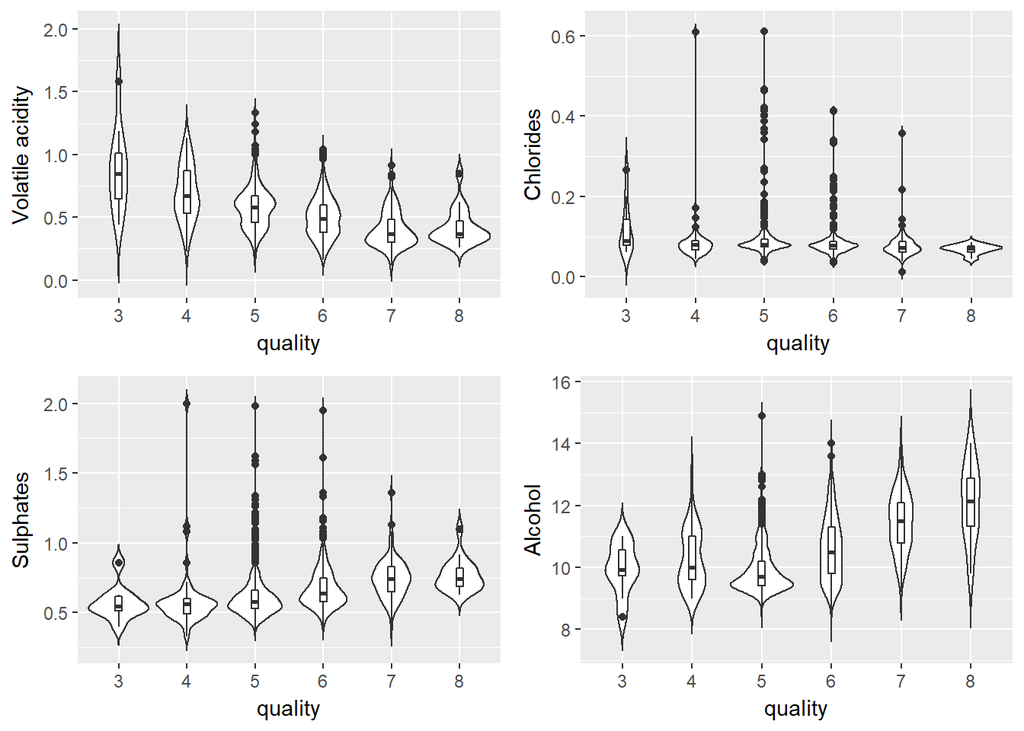

**Observations:**

- Fixed Acidity mean increases as quality increases with a peak at 8.8 g/dm^3. Almost logistic but with more variance at quality level 8.
- **Volatile acidity decreases as quality increases and has less variance** **as quality increases as well**.
- Citric acid follow a positive linear behaviour as quality increases.
- Residual Sugar doesn’t have a linear behaviour with quality.
- **Chlorides (once ouliers are excluded) seems to follow a linear model** against quality by looking at conditional summary.
- The same goes for pH and density. There is a relation with quality but not completely linear.
- Alcohol has a strong correlation to quality **except for level 5** but as the violin plot shows it shows outliers and particular behaviour compared to other levels.
- **Sulphates seems to have a linear pattern to quality**.

# Bivariate Analysis

### Talk about some of the relationships you observed in this part of the investigation. How did the feature(s) of interest vary with other features in the dataset?

We have some strong relations: * Between variables related to acidity: fixed acidity, volatile acidity, citric acid and pH, been Volatile acidity the one with higuest correlation to quality. **I conclude red wines with less volatile acidity levels tend to have high quality**.

### Did you observe any interesting relationships between the other features (not the main feature(s) of interest)?

Density also have a relation to acidity variables specially to Fixed acidity (0.668).

It’s interest that Density is also related to alcohol (-0.50). So, it seems density can be a link been acidity variables and alcohol/sulphates variables to define quality.

### What was the strongest relationship you found?

- pH and Fixed acidity was the strongest with 0.68.
- **Compared to quality, Alcohol with 0.48 was the strongest. Followed by** **volatile acidity**

# Multivariate Plots Section

> **Quality levels grouping:** to simplify analysis I’ve collapsed quality levels from 6 to 4 levels. This will visualize more easily the patterns between variables that affect quality.

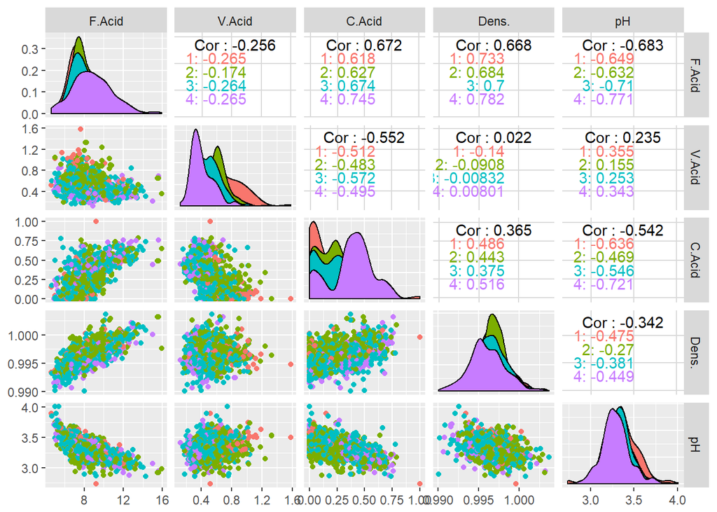

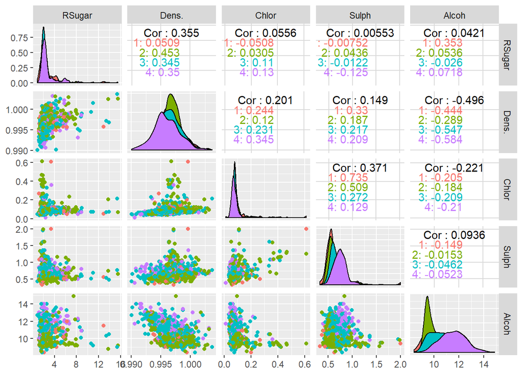

**Other interesting variables that relates to quality**

Fixed acidity and density show a positive correlation that translates also into quality.

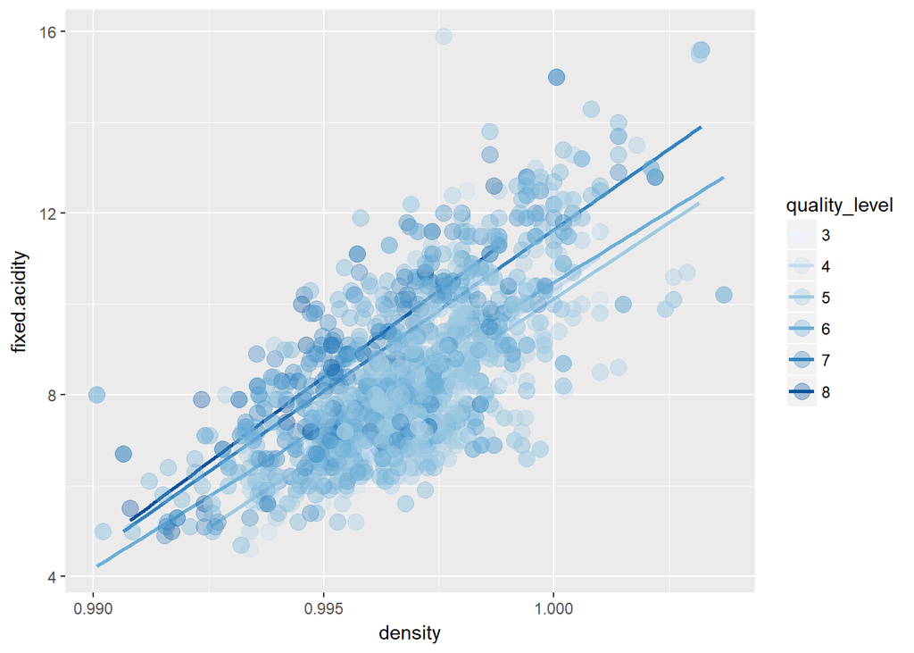

Alcohol and density show also a correlation that translates into quality

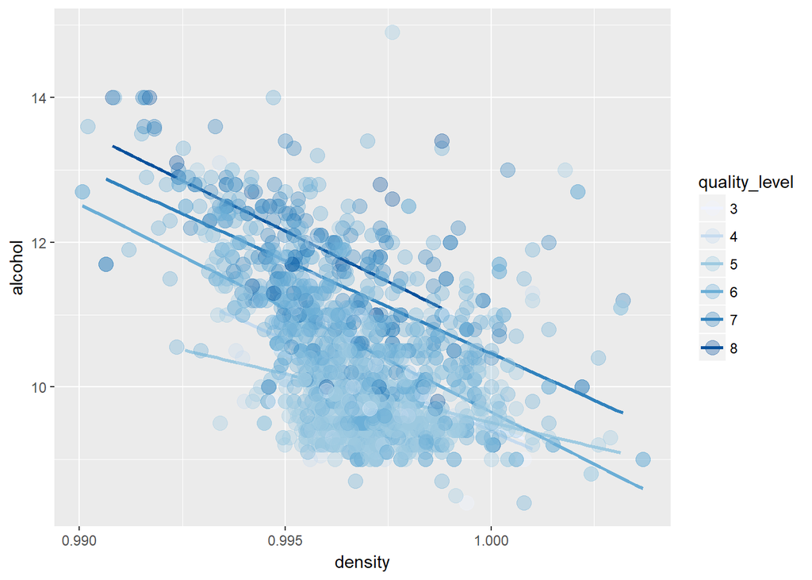

# Multivariate Analysis

By selecting the variables that are more related to quality grouped by: 1. Alcoholic (excluding density and suger residuals since are related to alcohol) 2. Acidity (volatile, since others like pH, Citric and Fixed are related as well) 3. Sulphates 3. Chloridic 4. SO2 (i included SO2 since it improved the model a little bit)

This is the model:

```r
m1 <- lm(quality ~ alcohol, data = pf)
m2 <- update(m1, ~ . + volatile.acidity)
m3 <- update(m2, ~ . + I(log(sulphates)))
m4 <- update(m3, ~ . + chlorides)
m5 <- update(m4, ~ . + total.sulfur.dioxide)
mtable(m1, m2, m2, m3, m4, m5)
```

```
##
## Calls:
## m1: lm(formula = quality ~ alcohol, data = pf)
## m2: lm(formula = quality ~ alcohol + volatile.acidity, data = pf)
## m2: lm(formula = quality ~ alcohol + volatile.acidity, data = pf)
## m3: lm(formula = quality ~ alcohol + volatile.acidity + I(log(sulphates)),
##     data = pf)
## m4: lm(formula = quality ~ alcohol + volatile.acidity + I(log(sulphates)) +
##     chlorides, data = pf)
## m5: lm(formula = quality ~ alcohol + volatile.acidity + I(log(sulphates)) +
##     chlorides + total.sulfur.dioxide, data = pf)
##
## ============================================================================================================
##                              m1            m2            m2            m3            m4            m5
## ------------------------------------------------------------------------------------------------------------
##   (Intercept)               1.875***      3.095***      3.095***      3.369***      3.742***      3.998***
##                            (0.175)       (0.184)       (0.184)       (0.184)       (0.201)       (0.208)
##   alcohol                   0.361***      0.314***      0.314***      0.303***      0.285***      0.270***
##                            (0.017)       (0.016)       (0.016)       (0.016)       (0.016)       (0.016)
##   volatile.acidity                       -1.384***     -1.384***     -1.156***     -1.099***     -1.076***
##                                          (0.095)       (0.095)       (0.097)       (0.098)       (0.097)
##   I(log(sulphates))                                                   0.641***      0.779***      0.801***
##                                                                      (0.077)       (0.083)       (0.082)
##   chlorides                                                                        -1.694***     -1.729***
##                                                                                    (0.383)       (0.380)
##   total.sulfur.dioxide                                                                           -0.002***
##                                                                                                  (0.001)
## ------------------------------------------------------------------------------------------------------------
##   R-squared                 0.227         0.317         0.317         0.345         0.353         0.361
##   adj. R-squared            0.226         0.316         0.316         0.344         0.352         0.359
##   sigma                     0.710         0.668         0.668         0.654         0.650         0.646
##   F                       468.267       370.379       370.379       280.646       217.837       180.338
##   p                         0.000         0.000         0.000         0.000         0.000         0.000
##   Log-likelihood        -1721.057     -1621.814     -1621.814     -1587.752     -1577.984     -1568.023
##   Deviance                805.870       711.796       711.796       682.108       673.825       665.482
##   AIC                    3448.114      3251.628      3251.628      3185.503      3167.967      3150.046
##   BIC                    3464.245      3273.136      3273.136      3212.389      3200.230      3187.686
##   N                      1599          1599          1599          1599          1599          1599
## ============================================================================================================
```

### Talk about some of the relationships you observed in this part of the investigation. Were there features that strengthened each other in terms of looking at your feature(s) of interest?

I focused on those variables with high correlation to quality and more linear behaviour:

- Alcohol
- Volatile acidity
- Sulphates (logistic)
- Chlorides

Other variables were not used to prevent redundancy, for example, citric acid, fixed acidity, pH and density are related to Volatile Acidity anyway.

Density is also related to alcohol. Sugar Residual and SO2 were not highly related to quality. I included Total SO2 to improve some more the model but it’s marginal.

Even with the model its quite difficult to get a model with a strongher Rsquared since for some quality levels there are not enough observations. That’s why I opted to collapese and merge some levels.

### Were there any interesting or surprising interactions between features?

Yes, density requires more analysis and SO2 variables as well since they show complex relations to quality.

# Final Plots and Summary

### Plot One

```
             3      4       5       6       7       8
```

Alcohol Median 9.925 10.000 9.700 10.500 11.500 12.150

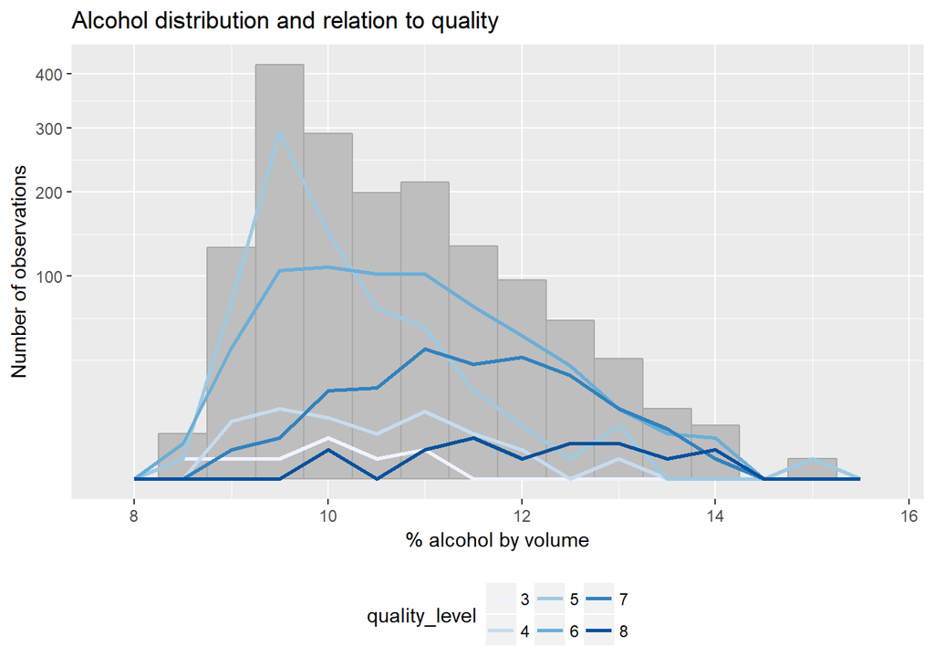

### Description One

Starting at level 5, Alcohol follow a strong linear relation to quality. Levels 3 and 4 are more volatile even level 4 is bimodal.

### Plot Two

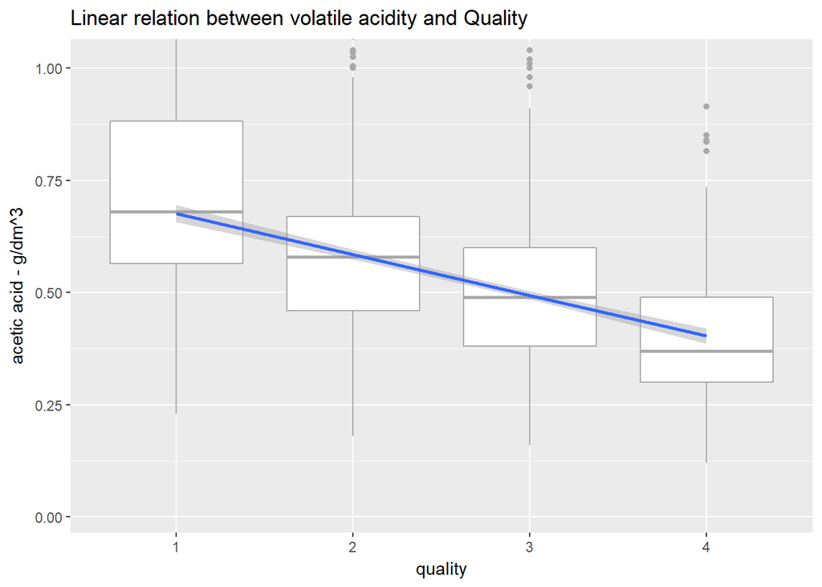

### Description Two

Volatile acidity follow a linear patterns agains quality. Sadly, quality levels 3 and 8 don’t have enough observations to show a better linear model. If we collapse to 4 quality levels you can show a better behaviour.

### Plot Three

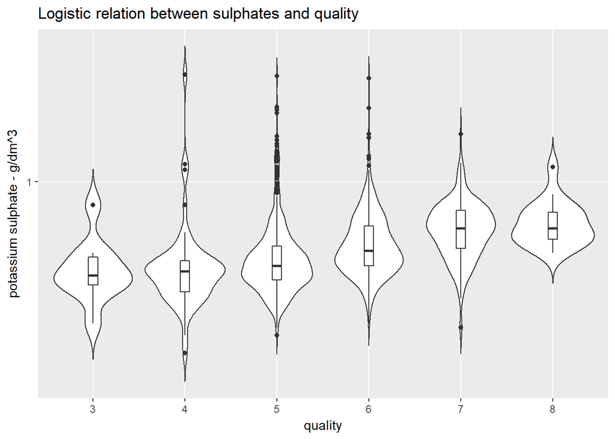

### Description Three

By using conditional summaries we can see there is a logistic line to describe quality based on sulphates with a upper limit at 0.740 g/dm3.

# Reflection

The model was simple in the sense that all variables were continuos. Plotting distributions and relationships was easy with ggplot and specially ggpairs to see multiple plots at once is just great. Using violin-plots to identify the impact of outlier and strange distributions is great too. But at the end one of the main tools I used to double check my finding was the conditional summaries table.

Once I analyzed relationship between input variables I decided to go for 4 variables since they were related to quality and they also had strong relations to other “secondary” variables like citric acid, pH, density, sugar residual and fixed acidity.

- Alcohol
- Volatile acidity
- Sulphate
- Chloride

I thouht Citric Acid would play a mayor role in my model but at the end it didn’t help that much.

Challenges:

Quality levels with just a few observations. I spent the last weeks trying to figure it out how to deal with just a few observations at quality level 3 and 8. Without using inference statistics I opted to grouped those categories to see more patterns and then decide an approach.

Most variables don’t have a well defined linear relationship with quality variable so more complex analysis need to be applied to improve the model. For example SO2 variables have concave shapes.

Removing or hidding outliers. In most cases I just used coord_cartesian to visually exlude them without affecting the results since I didn’t had much more information to decide it they were contamination or valid data.

Future analysis:

Density is an interesting variable. It links acidity variables and alcohol/sulfur variables and has a great pattern to model classification since quality levels seems to follow linear models as well.